# EMPLOYEE TURNOVER

## 8.4 Decision Tree Model

We can define decision trees succinctly as follows;

> [A decision tree is a decision support tool that uses a tree-like model of decisions and their possible consequences, including chance event outcomes, resource costs, and utility. It is one way to display an algorithm that only contains conditional control statements](https://en.wikipedia.org/wiki/Decision_tree).

The Corporate Finance Institute also offer a definition that allows us to better visualise the structure of decision trees.

> [A decision tree is a support tool with a tree-like structure that models probable outcomes, cost of resources, utilities, and possible consequences. Decision trees provide a way to present algorithms with conditional control statements. They include branches that represent decision-making steps that can lead to a favorable result](https://corporatefinanceinstitute.com/resources/knowledge/other/decision-tree/).

Typically, a decision tree model uses recursive partitioning. Each partition arises from a decision. There are two key types of nodes.

- The decision node: This is a node where a decision is made and a split occurs. Typically, a decision tree will split the data multiple times based on certain cut offs in the features or independent [variables](https://christophm.github.io/interpretable-ml-book/tree.html).
- Terminal node: These are nodes that come last. They signify the peak of the tree branch and point to a decision.

Decision trees are easy to build, read, and interpret. Also, decision trees require less data cleaning as they are minimally affected by missing values and outliers. However, decision trees can be unstable with slight changes in data and are prone to over fitting. Finally, decision trees may not be very effective when dealing with a continuous dependent variable. Hence, it is critical to tune hyper parameters for decision trees. In particular, the following parameters key:

- Tree depth:
- Cost complexity:

```r
decision_tree_model <- decision_tree(

  cost_complexity = tune(),

  tree_depth = tune()

) %>%

  set_engine("rpart") %>%

  set_mode("classification")
```

```r
tree_grid <- grid_regular(

  cost_complexity(),

  tree_depth(),

  levels = 5
)

head(tree_grid)
```

```
## # A tibble: 6 × 2
##   cost_complexity tree_depth
##             <dbl>      <int>
## 1    0.0000000001          1
## 2    0.0000000178          1
## 3    0.00000316            1
## 4    0.000562              1
## 5    0.1                   1
## 6    0.0000000001          4
```

Next, we create cross validation folds in the training data. We shall use these folds to tune the parameters.

```r
set.seed(200)
cell_folds <- vfold_cv(df_train)
```

We then fit the model to the folds by defining a workflow.

```r
tree_wf <- workflow() %>%

  add_recipe(df_recipe) %>%

  add_model(decision_tree_model)


tree_tune <- tree_wf %>%

  tune_grid(

    resamples = cell_folds,

    grid = tree_grid

  )
```

We can now see the metrics generated in the tuning process.

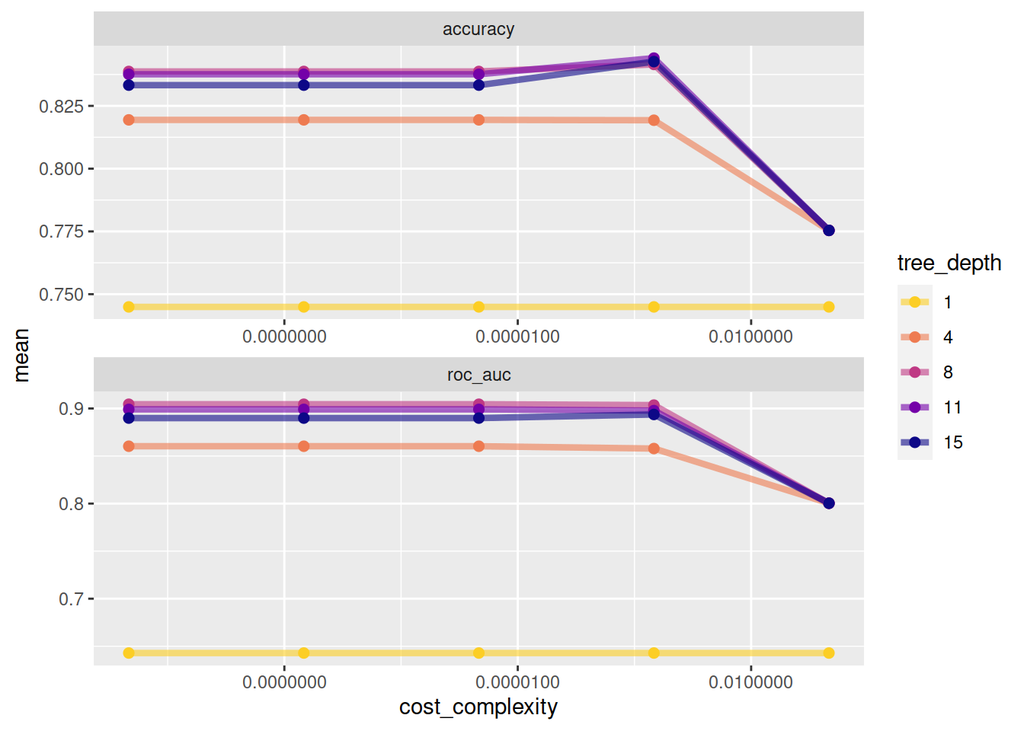

```r
tree_tune %>%

  collect_metrics() %>%

  mutate(tree_depth = factor(tree_depth)) %>%

  ggplot(aes(cost_complexity, mean, color = tree_depth)) +

  geom_line(size = 1.5, alpha = 0.6) +

  geom_point(size = 2) +

  facet_wrap(~ .metric, scales = "free", nrow = 2) +

  scale_x_log10(labels = scales::label_number()) +

  scale_color_viridis_d(option = "plasma",

                        begin = .9, end = 0)
```

Here, we see that a shallower tree has the worst performance on both metrics- AUC and Accuracy.

```r
tree_tune %>%

  collect_metrics()
```

```
## # A tibble: 50 × 8
##    cost_complexity tree_depth .metric  .estimator  mean     n std_err .config
##              <dbl>      <int> <chr>    <chr>      <dbl> <int>   <dbl> <chr>
##  1    0.0000000001          1 accuracy binary     0.745    10 0.00526 Preproces…
##  2    0.0000000001          1 roc_auc  binary     0.643    10 0.00562 Preproces…
##  3    0.0000000178          1 accuracy binary     0.745    10 0.00526 Preproces…
##  4    0.0000000178          1 roc_auc  binary     0.643    10 0.00562 Preproces…
##  5    0.00000316            1 accuracy binary     0.745    10 0.00526 Preproces…
##  6    0.00000316            1 roc_auc  binary     0.643    10 0.00562 Preproces…
##  7    0.000562              1 accuracy binary     0.745    10 0.00526 Preproces…
##  8    0.000562              1 roc_auc  binary     0.643    10 0.00562 Preproces…
##  9    0.1                   1 accuracy binary     0.745    10 0.00526 Preproces…
## 10    0.1                   1 roc_auc  binary     0.643    10 0.00562 Preproces…
## # … with 40 more rows
```

Here, we select the best tree.

```r
best_tree <- tree_tune %>%

  select_best("roc_auc")
```

```r
final_tree <- tree_wf %>%

    finalize_workflow(best_tree) %>%

    fit(data = df_train)
```

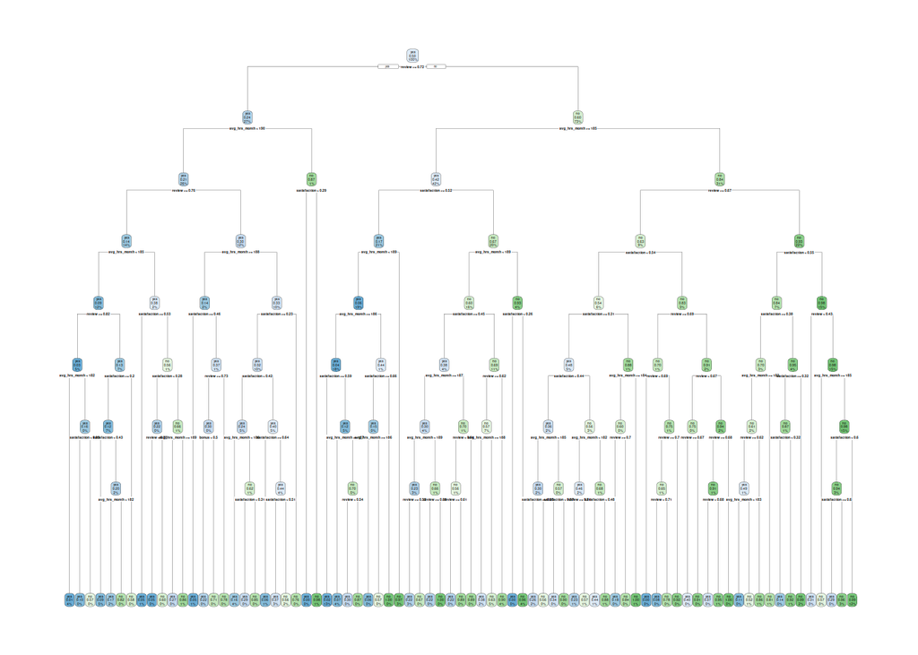

```r
final_tree %>%

  extract_fit_engine() %>%

  rpart.plot(roundint = FALSE)
```

We then do the predictions on the test set, generate metrics and and plot the ROC curve.

```r
final_tree %>%

  augment(new_data = df_test) %>%

  conf_mat(truth = left, estimate = .pred_class) %>%

  summary()
```

```
## # A tibble: 13 × 3
##    .metric              .estimator .estimate
##    <chr>                <chr>          <dbl>
##  1 accuracy             binary         0.823
##  2 kap                  binary         0.594
##  3 sens                 binary         0.792
##  4 spec                 binary         0.835
##  5 ppv                  binary         0.665
##  6 npv                  binary         0.907
##  7 mcc                  binary         0.599
##  8 j_index              binary         0.627
##  9 bal_accuracy         binary         0.814
## 10 detection_prevalence binary         0.348
## 11 precision            binary         0.665
## 12 recall               binary         0.792
## 13 f_meas               binary         0.723
```

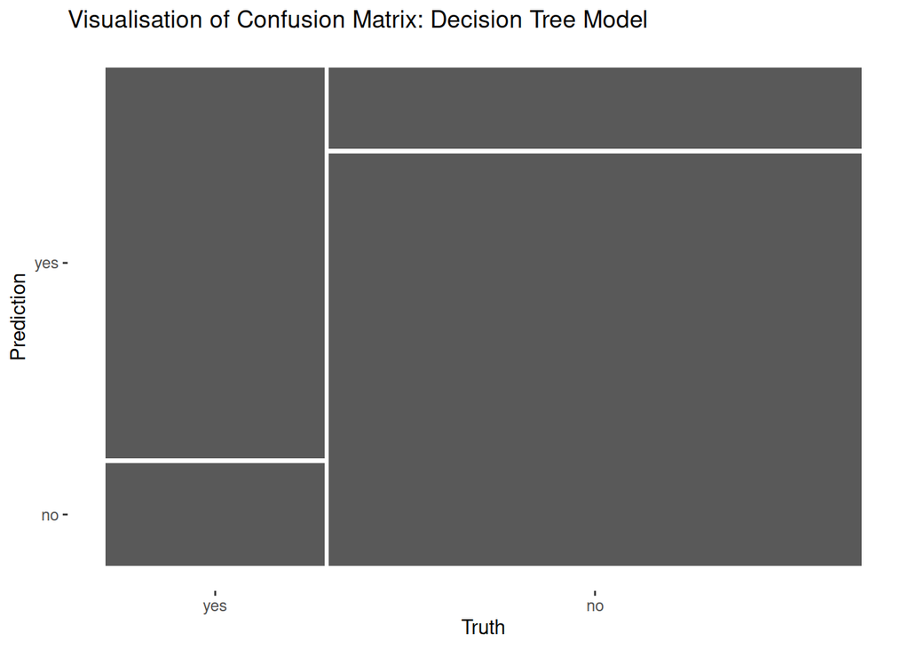

```r
final_tree %>%

  augment(new_data = df_test) %>%

  conf_mat(truth = left, estimate = .pred_class) %>%

  autoplot() +

  labs(title = "Visualisation of Confusion Matrix: Decision Tree Model")
```

```r
final_tree %>%

  augment(new_data = df_test) %>%

  roc_auc(truth = left, .pred_yes)
```

```
## # A tibble: 1 × 3
##   .metric .estimator .estimate
##   <chr>   <chr>          <dbl>
## 1 roc_auc binary         0.897
```

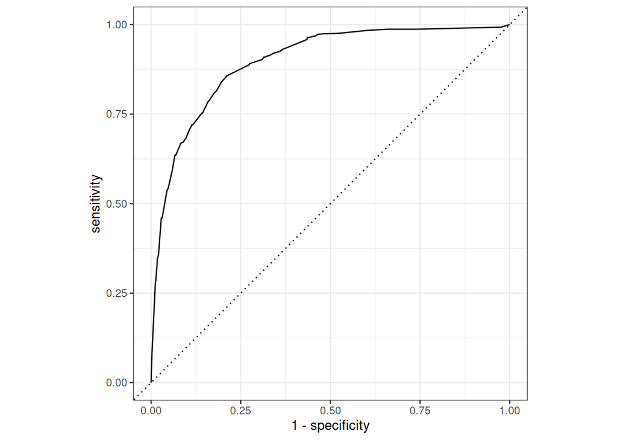

```r
final_tree %>%

  augment(new_data = df_test) %>%

  roc_curve(truth = left, .pred_yes) %>%

  autoplot()
```

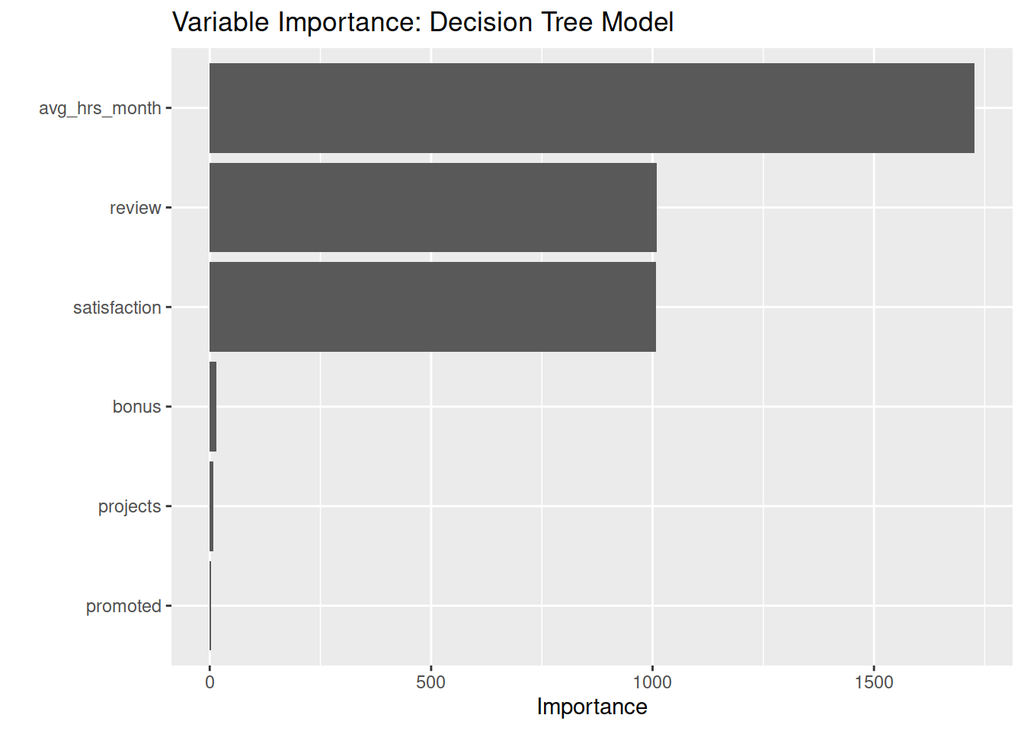

```r
final_tree %>%

  extract_fit_engine() %>%

  vip() +

  labs(title = "Variable Importance: Decision Tree Model")
```

## 8.5 Random Forest Model

```r
rand_model <- rand_forest() %>%

  set_engine("ranger", importance = "impurity") %>%

  set_mode("classification")
```

```r
## Create a workflow
random_model_fit <- workflow() %>%

  add_recipe(df_recipe) %>%

  add_model(rand_model) %>%

  fit(data = df_train)
```

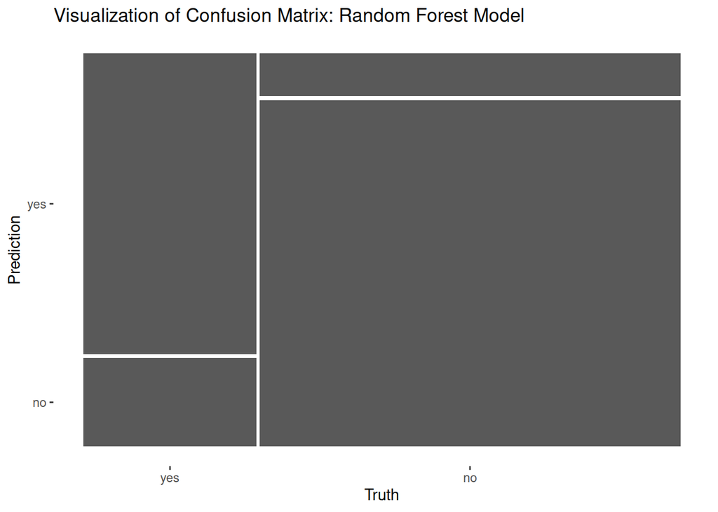

```r
## Predictions
random_model_fit %>%

  augment(new_data = df_test) %>%

  conf_mat(truth = left, estimate = .pred_class) %>%

  autoplot() +

  labs(title = "Visualization of Confusion Matrix: Random Forest Model")
```

```r
## Predictions
random_model_fit %>%

  augment(new_data = df_test) %>%

  conf_mat(truth = left, estimate = .pred_class) %>%

  summary()
```

```
## # A tibble: 13 × 3
##    .metric              .estimator .estimate
##    <chr>                <chr>          <dbl>
##  1 accuracy             binary         0.856
##  2 kap                  binary         0.655
##  3 sens                 binary         0.773
##  4 spec                 binary         0.890
##  5 ppv                  binary         0.743
##  6 npv                  binary         0.905
##  7 mcc                  binary         0.655
##  8 j_index              binary         0.663
##  9 bal_accuracy         binary         0.831
## 10 detection_prevalence binary         0.304
## 11 precision            binary         0.743
## 12 recall               binary         0.773
## 13 f_meas               binary         0.758
```

```r
random_model_fit %>%

  augment(new_data = df_test) %>%

  roc_auc(truth = left, .pred_yes)
```

```
## # A tibble: 1 × 3
##   .metric .estimator .estimate
##   <chr>   <chr>          <dbl>
## 1 roc_auc binary         0.920
```

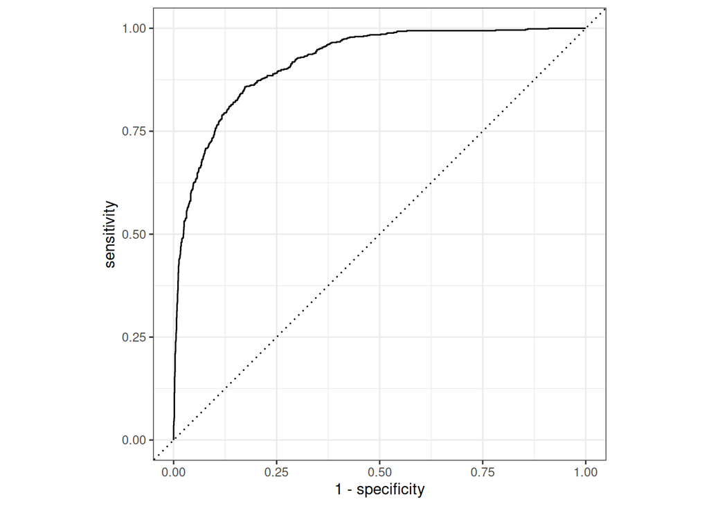

```r
random_model_fit %>%

  augment(new_data = df_test) %>%

  roc_curve(truth = left, .pred_yes) %>%

  autoplot()
```

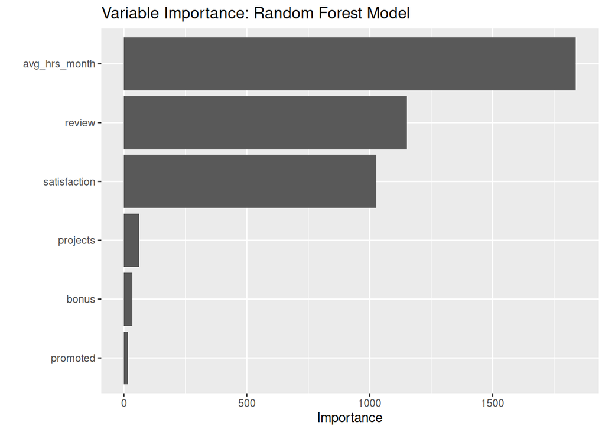

```r
random_model_fit %>%

  extract_fit_engine() %>%

  vip() +

  labs(title = "Variable Importance: Random Forest Model")
```

## 8.6 K-Nearest Neighbours (KNN) Model

```r
knn_model <- nearest_neighbor(

  neighbors = tune()

) %>%

  set_engine("kknn") %>%

  set_mode("classification")
```

```r
knn_wf <- workflow() %>%

  add_recipe(df_recipe) %>%

  add_model(knn_model)
```

```r
neighbours_grid <- tibble(neighbors = seq(from = 5, to = 100,

                                          by = 5))


knn_tune <- knn_wf %>%

  tune_grid(

    resamples = cell_folds,

    grid = neighbours_grid

  )
```

```r
knn_tune_best <- knn_tune %>%

  select_best("roc_auc")
```

```r
final_knn_model <- knn_wf %>%

  finalize_workflow(knn_tune_best) %>%

  fit(data = df_train)
```

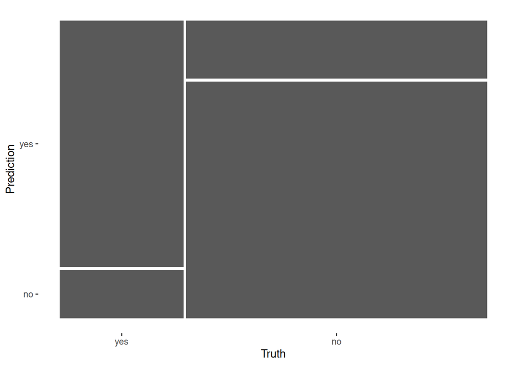

```r
final_knn_model %>%

  augment(new_data = df_test) %>%

  conf_mat(truth = left, estimate = .pred_class) %>%

  autoplot()
```

```r
final_knn_model %>%

  augment(new_data = df_test) %>%

  conf_mat(truth = left, estimate = .pred_class) %>%

  summary()
```

```
## # A tibble: 13 × 3
##    .metric              .estimator .estimate
##    <chr>                <chr>          <dbl>
##  1 accuracy             binary         0.813
##  2 kap                  binary         0.585
##  3 sens                 binary         0.836
##  4 spec                 binary         0.803
##  5 ppv                  binary         0.636
##  6 npv                  binary         0.922
##  7 mcc                  binary         0.597
##  8 j_index              binary         0.639
##  9 bal_accuracy         binary         0.820
## 10 detection_prevalence binary         0.384
## 11 precision            binary         0.636
## 12 recall               binary         0.836
## 13 f_meas               binary         0.723
```

```r
final_knn_model %>%

  augment(new_data = df_test) %>%

  roc_auc(truth = left, .pred_yes)
```

```
## # A tibble: 1 × 3
##   .metric .estimator .estimate
##   <chr>   <chr>          <dbl>
## 1 roc_auc binary         0.906
```

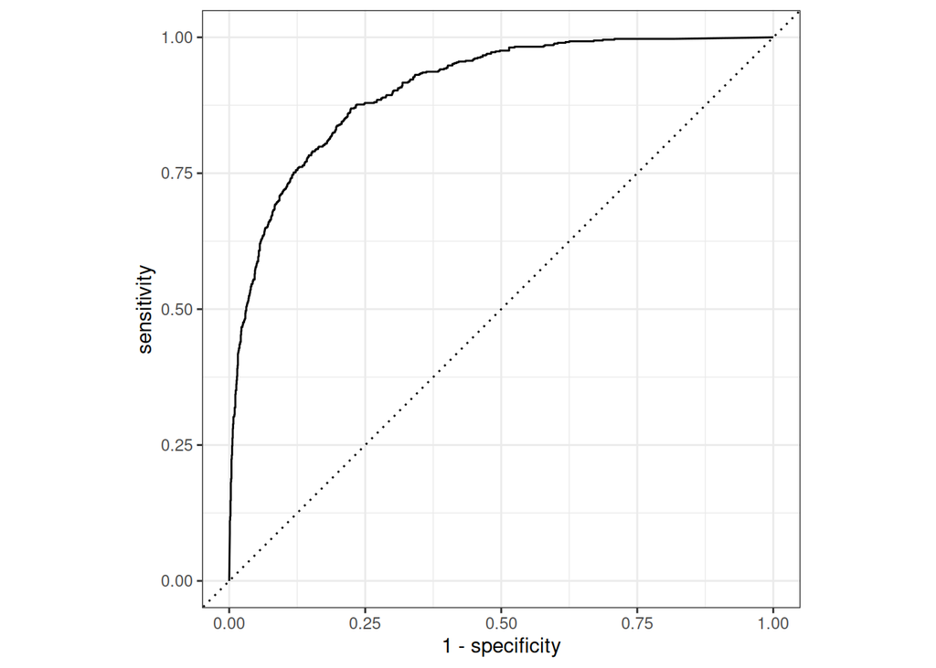

```r
final_knn_model %>%

  augment(new_data = df_test) %>%

  roc_curve(truth = left, .pred_yes) %>%

  autoplot()
```